# OpenPV API: Part I

Vishal Bakshi  
August 29, 2017  
vbakshi@ccsf.edu

source: https://developer.nrel.gov/docs/solar/openpv/

## Objective

The National Renewable Energy Laboratory (NREL) offers access to a variety of APIs related to clean energy data across the United States. The OpenPV project provides "real-time status of the solar photovoltaic market in the U.S.". In this post, I explore the use of the OpenPV API, mainly to practice importing and converting JSON files into a useful pandas DataFrame, and to learn how to use the [Basemap](https://matplotlib.org/basemap/) package for visualization. This process also leads me to some comparisons between average cost per Watt for different states and install sizes across the U.S.

```python
import pandas as pd
import numpy as np
import json
import requests
import matplotlib.pyplot as plt

from __future__ import print_function, division
from pandas.io.json import json_normalize
from mpl_toolkits.basemap import Basemap
from matplotlib.colors import rgb2hex, Normalize
from matplotlib.cm import ScalarMappable
from matplotlib.colorbar import ColorbarBase
from matplotlib.patches import Polygon
```

```python
from IPython.core.display import HTML
HTML("""
<style>
.output_png {
    display: table-cell;
    text-align: center;
    vertical-align: middle;
}
</style>
""")
```

## Sending Requests

I create a list of state abbreviations and state names in order to add them as a parameter in my request, and to use for creating a dictionary when plotting the map:

```python
states = []
fin = open('states.txt')
for line in fin:
    line = line.strip()
    states.append(line)

state_names = []
fin = open("state_names.txt")
for line in fin:
    line = line.strip()
    state_names.append(line)
```

```python
rs = []
s = requests.Session()
for state in states:
    try:
        url ="https://developer.nrel.gov/api/solar/open_pv/installs/index?&api_key=#&nppage=1300000&format=JSON&state=" + state
        r = json.loads(s.get(url).text)
        rs.append(r)
    except:
        continue
```

When I looped through each state for the `state` parameter, I kept retrieving only 49/50 states. California's data was not being returned so I create a seperate request for `state=CA` (there were a total of 628616 installs in for California in the NREL database so I chose 10000 installs per page over 63 pages):

```python
a = requests.Session()
cas = []
for i in range(63):
    try:
        url ="https://developer.nrel.gov/api/solar/open_pv/installs/index?&api_key=#&nppage=10000&format=JSON&state=CA&" + "pagenum=" + str(i+1)
        ca = json.loads(a.get(url).text)
        cas.append(ca)
    except:
        continue
```

Each JSON output includes a list of `results` dictionaries, and each dictionary contains the following outputs:

- ID
- Cost per Watt
- Data Installed
- Size (in kW)
- State
- Zipcode

I created DataFrames for the 49 states and California using `json_normalize`, appended the CA DataFrame to the DataFrame with the other 49 states' install info, and exported them to a pickle file.

```python
df = json_normalize(rs, u'result', [u'inputs', u'metadata', u'limit', u'offset', u'total_pages', u'version'], errors='ignore')
df2 = json_normalize(cas, u'result', [u'inputs', u'metadata', u'limit', u'offset', u'total_pages', u'version'], errors='ignore')
data = df.append(df2)
data.to_pickle("full_data.pkl")
```

I now bring in that DataFrame for further analysis...

```python
data = pd.read_pickle("full_data.pkl")
```

..and check the `value_counts` with the [NREL database online](https://openpv.nrel.gov/search)

```python
data.state.value_counts().sort_index().head()
```

```
AK        22
AL        32
AR       239
AZ     89360
CA    626818
Name: state, dtype: int64
```

## Visualizing the Data: Bar Plot

I want to visualize the average cost per Watt for each state, so I drop NaN and 'n/a' records from the `cost` and `size_kw` fields, and then create a bar plot showing the average cost per watt for each state:

```python
cost_df = data.dropna(subset=['cost', 'size_kw'])
cost_df = cost_df.query('cost != "n/a"')
cost_df['size_w'] = cost_df.size_kw * 1000
cost_df['avg_cost'] = cost_df.cost.astype(int) / cost_df.size_w.astype(int)
```

```python
avg_cost = [group[1].avg_cost.mean() for group in cost_df.groupby('state')]
```

```python
avg_cost_dict = dict(zip(state_names, avg_cost))
```

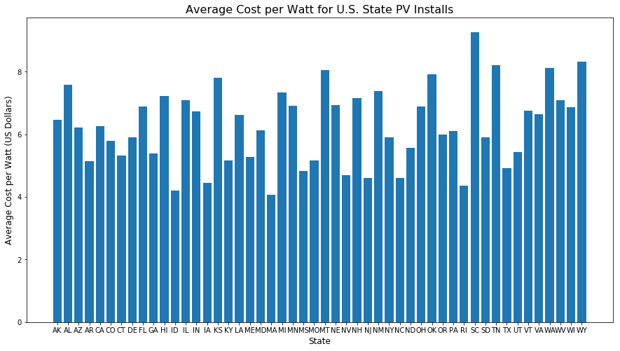

```python
fig, ax = plt.subplots(1, figsize=(15, 8))
xs = np.array(np.arange(0,50))
plt.xticks(xs, states)
ax.set_title('Average Cost per Watt for U.S. State PV Installs', fontsize=16)
ax.set_xlabel('State', fontsize=12)
ax.set_ylabel('Average Cost per Watt (US Dollars)', fontsize=12)
plt.bar(xs, avg_cost)
plt.show()
```

**Figure 1**: Average Cost per Watt (in US Dollars) for U.S. State PV Installs

## Visualizing the Data: Basemap

A better visualization of the average cost can be done on a map of the United States using a colormap corresponding to the cost range. I referenced fillstates.py on GitHub as well as a relevant [stackoverflow post](https://stackoverflow.com/questions/39742305/how-to-use-basemap-python-to-plot-us-with-50-states) to create this map.

```python
vmin = min(avg_cost_dict.values())
vmax = max(avg_cost_dict.values())
vmax, vmin
```

```
(9.2670580097715067, 4.0759874540820462)
```

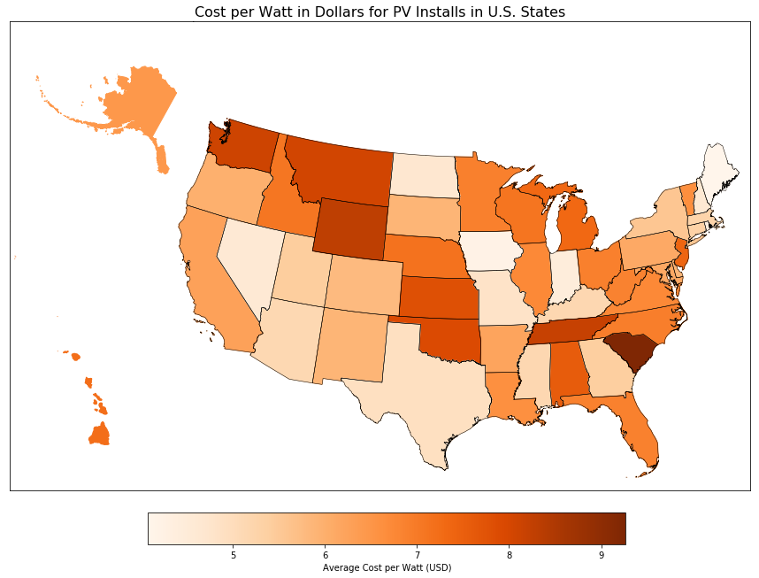

```python
fig, ax = plt.subplots(1)
fig.set_size_inches(15, 10)

m = Basemap(llcrnrlon=-130, llcrnrlat=18, urcrnrlon=-60,urcrnrlat=54.9, projection='lcc', lat_1 = 33, lat_2=45, lon_0=-95)
shp_info = m.readshapefile('cb_2016_us_state_500k', 'states', drawbounds=True)
colors = {}
statenames = []
cmap = plt.cm.Oranges
vmin = min(avg_cost_dict.values())
vmax = max(avg_cost_dict.values())

for shapedict in m.states_info:
    statename = shapedict['NAME']
    if statename in state_names:
        cost = avg_cost_dict[statename]
        colors[statename] = cmap(abs(cost-vmin)/(vmax-vmin))[:3]
    statenames.append(statename)

for nshape, seg in enumerate(m.states):
    if statenames[nshape] in state_names:
        if statenames[nshape] == 'Alaska':
            seg = list(map(lambda (x,y): (0.35*x + 750000, 0.35*y + 1250000), seg))
        if statenames[nshape] == 'Hawaii':
            seg = list(map(lambda (x,y): (1.3*x + 3800000, 1.3*y-1600000), seg))

        color = rgb2hex(colors[statenames[nshape]])
        poly = Polygon(seg, facecolor=color, edgecolor=color)
        ax.add_patch(poly)


norm = Normalize(vmin=vmin, vmax=vmax)
mapper = ScalarMappable(norm=norm, cmap=cmap)
cax = fig.add_axes([0.27, 0.05, 0.5, 0.05])
cb = ColorbarBase(cax, cmap=cmap, norm=norm, orientation='horizontal')
cb.ax.set_xlabel('Average Cost per Watt (USD)')
ax.set_title('Cost per Watt in Dollars for PV Installs in U.S. States', fontsize=16)
plt.show()
```

**Figure 2**: Average Cost per Watt (in US Dollars) for U.S. State PV Installs

(Alaska and Hawaii scaled and repositioned for visual clarity)

The average cost per watt corresponds to the lightness of the color orange, so states like Iowa and Nevada have a lower cost per watt (in Dollars) than say South Carolina or Wyoming.

## Average Cost Based on System Size

The map above shows average cost per Watt for each state, including all PV system sizes. In order to better understand how each state is managing costs for PV installs, I'll create different ranges of kW size and plot the average cost for each state for each range. First I plot the CDF of PV system size (in Watts) and determine the 90th percentile:

```
90th %-ile occurs at 2283260 watts
```

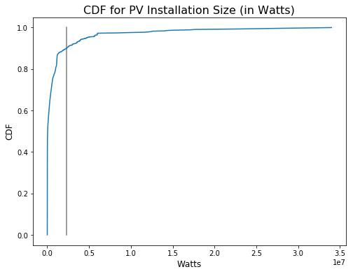

```python
xs = np.sort(np.asarray(cost_df.size_w))
watts = np.cumsum(xs / xs.sum())
x90 = xs[np.argwhere(watts > 0.90)[0]]

fig, ax = plt.subplots(1, figsize=(8, 6))
ax.set_xlabel('Watts', fontsize=12)
ax.set_ylabel('CDF', fontsize=12)
ax.set_title('CDF for PV Installation Size (in Watts)', fontsize=16)
plt.plot([x90, x90], [0, 1], color='gray')
plt.plot(xs, watts)

print('90th %%-ile occurs at %d watts' % x90)
plt.show()
```

**Figure 3**: Cumulative Distribution Function for PV Install Size (in Watts)

Next, I'll examine the CDF between 0 and 0.90 to determine if there are any distinct intervals where the CDF's rate of increase is constant:

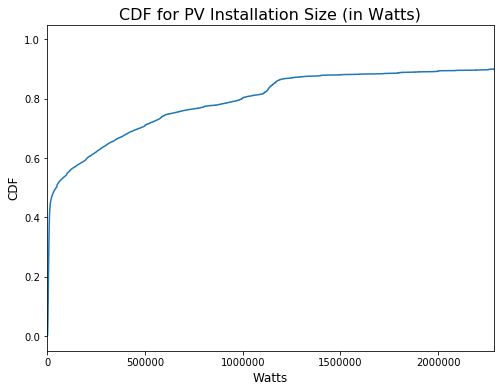

```python
fig, ax = plt.subplots(1, figsize=(8, 6))

ax.set_xlabel('Watts', fontsize=12)
ax.set_ylabel('CDF', fontsize=12)
ax.set_title('CDF for PV Installation Size (in Watts)', fontsize=16)
ax.set_xlim([0, x90])
plt.plot(xs, watts)
plt.show()
```

**Figure 4**: Cumulative Distribution Function for PV Install Size (in Watts)

*Up to 90th Percentile*

There seem to be three broad regions with relatively constant slopes:

- 0th to 40th Percentile
- 40th to 75th percentile
- 75th percentile and above

```python
x40 = xs[np.argwhere(watts > 0.40)[0]]
x75 = xs[np.argwhere(watts > 0.75)[0]]
print("System Size in Watts Corresponding to 40th %-ile, 75th %-ile and maximum overall")
x40[0], x75[0], xs.max()
```

```
System Size in Watts Corresponding to 40th %-ile, 75th %-ile and maximum overall
```

```
(11445.0, 631680.0, 34000000.0)
```

I'll create three categories of system size:

- Size A: 0 to 10000 watts
- Size B: 10000 to 500000 watts
- Size C: 500000 watts to 34000000 watts

In this case, each state may not have a PV system of a given size. When creating the Basemap, I use the items in the `state_names` list as keys for the `avg_cost_dict` when calculating the color associated with the given average cost relative to the maximum and minimum cost in that particular set of states. This no longer applies to each DataFrame so I will have to map the state name abbreviations existing in the DataFrame to a new field which contains the full name.

```python
state_dict = dict(zip(states, state_names))
cost_df['state_name'] = cost_df['state'].map(state_dict)
cost_df.state_name.head()
```

```
0     Alaska
8     Alaska
12    Alaska
14    Alaska
15    Alaska
Name: state_name, dtype: object
```

I set the bins to the size intervals mentioned above, and create three separate DataFrames for each size. I wrap the code for the Basemap plot as function and save it as a separate file `openpv.py`.

```python
bins = [0, 10000, 500000, 34000000]
group_names = ['A', 'B', 'C']
cost_df['categories'] = pd.cut(cost_df['size_w'], bins, labels=group_names)
```

```python
sizeA = cost_df.query('categories == "A"')
sizeB = cost_df.query('categories == "B"')
sizeC = cost_df.query('categories == "C"')
```

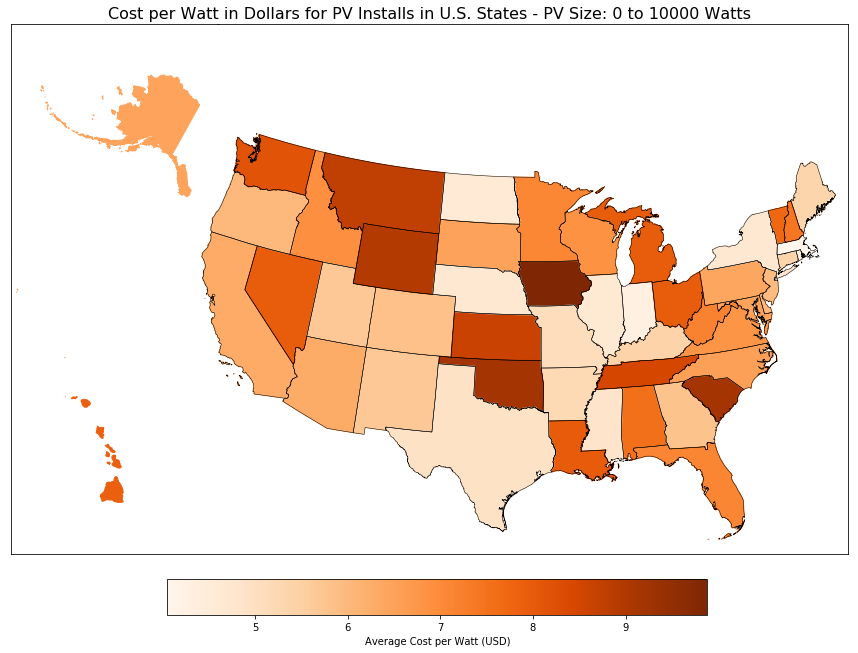

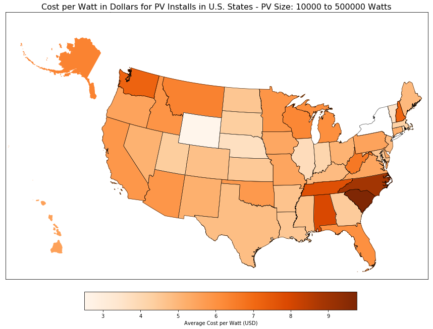

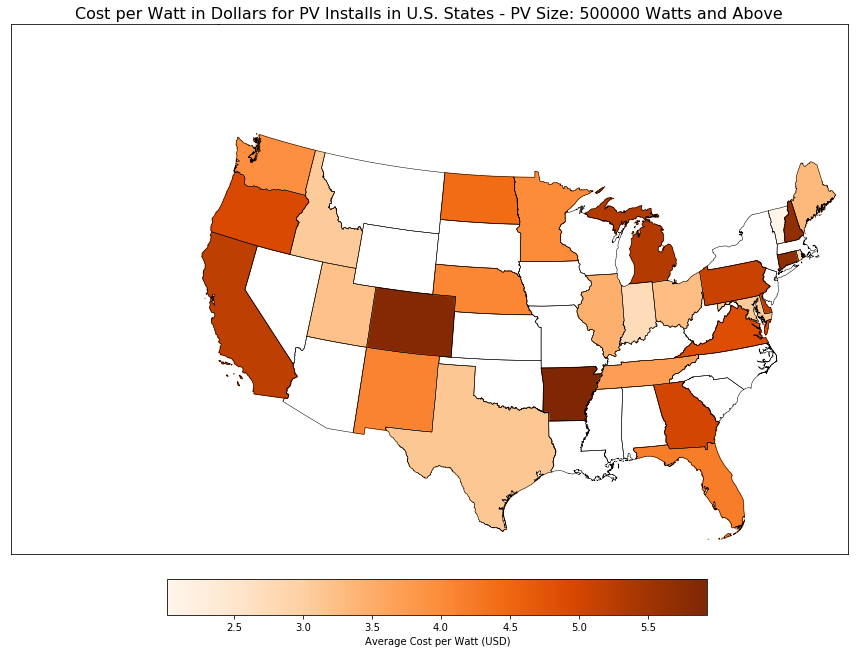

```python
import imp
import openpv
imp.reload(openpv)

sizes = [sizeA, sizeB, sizeC]
labels = ['0 to 10000 Watts', '10000 to 500000 Watts', '500000 Watts and Above']

for i, df in enumerate(sizes):
    openpv.AvgCostMap(df, state_dict, label=labels[i])
```

**Figure 5**: Average Cost per Watt Based on System Size

*Top: 0-10kW, Middle: 10-500kW, Bottom: 500+ kW*

Now I can make some more interesting observations. For example, my home state of Iowa has a lower average cost per Watt for PV systems that are between 10 to 500 kW than it does for systems 10 kW and below. States like Idaho have a lower cost per Watt for systems greater than 500 kW than for smaller systems. States like California have a relatively small difference in cost per Watt across all three size ranges. Overall, for all states included in the respective size ranges, there is an apparent decrease in cost as the size of the system increases:

| Size (kW): | 0-10 | 10-500 | 500+ |
| --- | --- | --- | --- |
| **Avg Cost per Watt** | \$6.00 | \$5.37 | \$4.82 |

**Table 1**: Size (kW) and corresponding Avg Cost per Watt (\$) for U.S. States

```python
sizeA.avg_cost.mean(), sizeB.avg_cost.mean(), sizeC.avg_cost.mean()
```

```
(5.9994270648771035, 5.3725774372071919, 4.819232936849378)
```

## Testing for Statistical Significance

I want to check the p-values of the difference in means between the size ranges. In order to determine if I can use the `ttest_ind` function from the `scipy` package, I'll check to see if the Central Limit Theorem applies to the distribution of `avg_cost` for each size range:

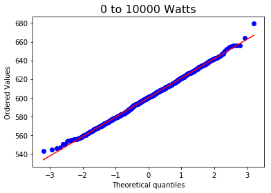

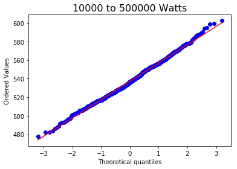

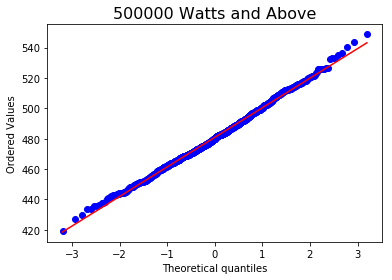

```python
from scipy import stats

for i, df in enumerate(sizes):
    fig, ax = plt.subplots(1)
    x = [np.sum(np.random.choice(df.avg_cost.values, size=100, replace=True)) for _ in range(1000)]
    res = stats.probplot(x, plot=ax)
    ax.set_title(labels[i], fontsize=16)
    plt.show()
```

For each size range, the distribution of the sums of sample values chosen at random are (very) close to being normally distributed so the CLT holds for the distribution of `avg_cost`.

First I check the p-value of each individual sample mean using `ttest_1samp` where the null hypothesis states that the mean of the sample is equal to the mean of the population. In this case the calculated mean of all values in a given size range are the "population":

```python
print('Size Range\tCalculated Mean\tp-value')
for i, df in enumerate(sizes):
    np.random.seed(1)
    mu = df.avg_cost.values.mean()
    p_value = stats.ttest_1samp(np.random.choice(df.avg_cost.values, size=int(0.1*len(df.avg_cost)), replace=True), mu)[1]
    print(labels[i]+'\t%0.3f\t%0.3f' % (mu, p_value))
```

```
Size Range	Calculated Mean	p-value
0 to 10000 Watts	5.999	0.887
10000 to 500000 Watts	5.373	0.222
500000 Watts and Above	4.819	0.752
```

For each Size Range the null hypothesis holds and there is strong to very strong evidence that the sample mean is equal to the population mean. Next, I compare the means from different size ranges and test the null hypothesis that the mean of each sample is identical. Since the length of each array must be equal, I chose the sample size to be 1000 which is about half of the smallest set of values, 2215 for `sizeC`:

```python
len(sizeA.avg_cost), len(sizeB.avg_cost), len(sizeC.avg_cost)
#(660418, 98343, 2215)

print('Means\tp-value')
perms = [(0, 1), (1, 2), (0, 2)]
labels = ['A vs B', 'B vs C', 'A vs C']

for i, perm in enumerate(perms):
    np.random.seed(2)
    sample1 = np.random.choice(sizes[perm[0]].avg_cost, 1000, replace=True)
    sample2 = np.random.choice(sizes[perm[1]].avg_cost, 1000, replace=True)
    p_value = stats.ttest_ind(sample1, sample2, equal_var=False)[1]
    print(labels[i] + '\t%0.5f' % p_value)
```

```
Means	p-value
A vs B	0.00000
B vs C	0.00000
A vs C	0.00000
```

`ttest_ind` is a two-sided test, so a one-sided test would have half the resulting p_values. From this test there is strong evidence to reject the null hypothesis and I can make a significant claim, based on this model, that as the size of the PV system increases the average cost decreases as demonstrated in **Table 1** above.

## Caveats and Next Steps

The issue of selecting sample size is the first source of my hesitancy to make a strong claim from this analysis, since I arbitrarily chose 1000 samples to compare the means of `avg_cost` from each size range. Next, collecting the mean `avg_cost` of each size range across different states into one array and concluding that the difference in means is significant overlooks the possibility that different states may use a different set of practices of designing, constructing and managing different sized PV systems, something that may affect the `avg_cost` of each type of system.

In order to further analyze these assumptions and potential sources of errors, I'll take a look in a future post at other sources for PV install data, such OpenPV's CSV dataset, which may contain more features of interest regarding the installs, clarifying the difference between the installs across different states.